# Why Do Multinational Firms Exist?

Stephen Weymouth

Dean’s Professor

2026-09-23

# In 2000 Steve Jobs handed out T-shirts that said “Mactories.” After 2003 Apple no longer assembled its own computers.

## Your IB Voice

Your explanation

After the 2000 tech crash Apple closed the factories it owned in Singapore and California, while Foxconn built a factory city in Shenzhen to do the same work. Why did the work leave one firm’s boundary (Apple) and enter another’s (Foxconn’s)?

**10 minutes**

## Competing explanations

Why did assembly leave Apple and enter Foxconn?

Chinese worker wages a fraction of Apple’s.

After the crash Apple could not pay for factories.

Foxconn built faster and better than Apple could.

Foxconn offered one-stop sourcing.

Important to differentiate factors that explain the timing, and those that explain the partner (firm+location).

# In 1976 China was poorer than sub-Saharan Africa. What changed?

## Deng opened zones where capitalism could be tried

[figure not shown]

In 1978 Deng Xiaoping opened coastal zones where foreign capital, rural migrants, and Hong Kong managers combined for production

Deng Xiaoping with Jimmy Carter, White House, [January 29, 1979](https://commons.wikimedia.org/wiki/File:Deng_Xiaoping_and_Jimmy_Carter_at_the_arrival_ceremony_for_the_Vice_Premier_of_China._-_NARA_-_183157-restored.jpg) · U.S. National Archives, public domain.

# Shenzhen, 1982. It had been a fishing village of fewer than 70,000 people.

# The same city in 2014. By the early 2000s it had seven million people.

## Terry Gou’s (Foxconn) innovative strategy

Acer and ASUS designed PCs for Western brands and then sold their own; Gou never sold a brand.

Foxconn paid for the molds and did procurement, manufacturing, and logistics under one roof.

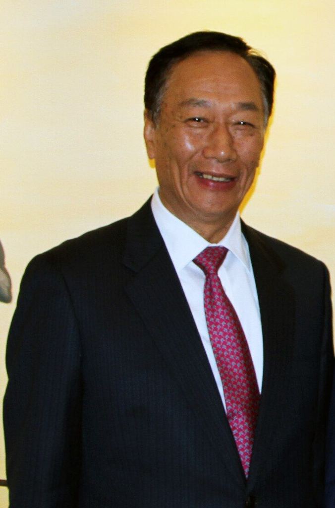

Terry Gou, [December 2017](https://commons.wikimedia.org/wiki/File:Terry_Gou_20171206.jpg) · U.S. Embassy Beijing, public domain.

“Once they get you in the door, that’s it. They control you.” - Rival supplier

## Foxconn grew 54X in eleven years

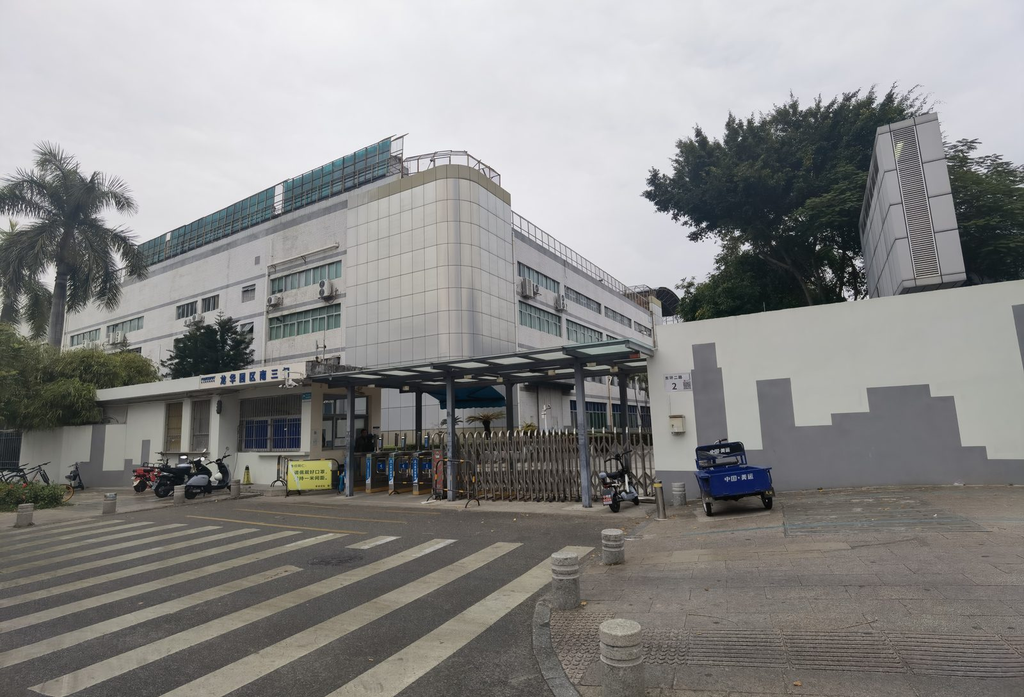

Revenue went from $1.8 billion in 1999 to $98 billion in 2010, which McGee calls “the consequence of one client more than any other: Apple.”

Lhzss8, [Foxconn Shenzhen campus](https://commons.wikimedia.org/wiki/File:富士康深圳园区.jpg), 2023 · Wikimedia Commons, CC BY-SA 4.0.

# Apple owned factories on three continents. Within two years it closed two of them. Why?

## Steve Jobs wanted more factories

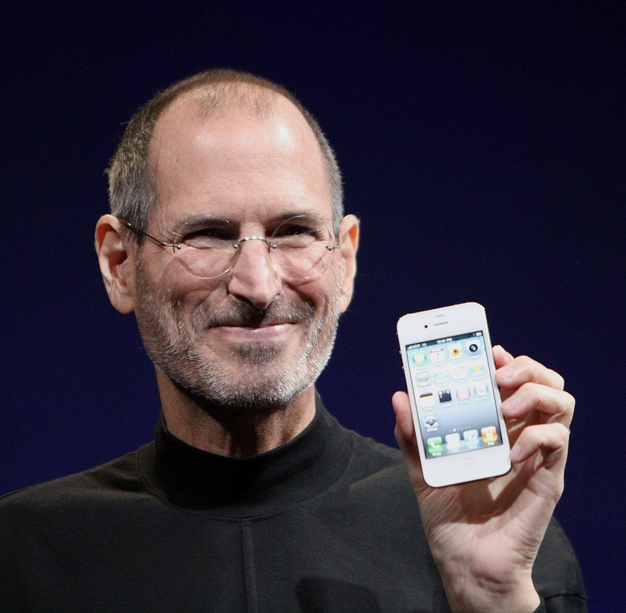

Matthew Yohe, [Steve Jobs, 2010](https://commons.wikimedia.org/wiki/File:Steve_Jobs_Headshot_2010-CROP.jpg) · Wikimedia Commons, CC BY-SA 3.0.

In 2000 Jobs handed out “Mactories” T-shirts and planned more plants.

In September 2000 the stock fell by more than half in a day.

In 2001 sales were at their lowest since 1989.

Apple had no cash for factories and not enough demand to justify them.

## Tim Cook made the case for outsourcing

Outsourcing was cheaper, faster, and nimbler, and it met Apple’s quality bar.

The strategy dated to 1996. The crash was “the nail in the coffin.”

Gou called Cook and said, “I can fix this.”

[figure not shown]

Monica M. Davey, Tim Cook and Steve Jobs · EPA/Shutterstock, credit as printed on the image; used for classroom discussion.

In two years the cost of doing it inside rose and the cost of buying fell.

## The search for cost and scale went global

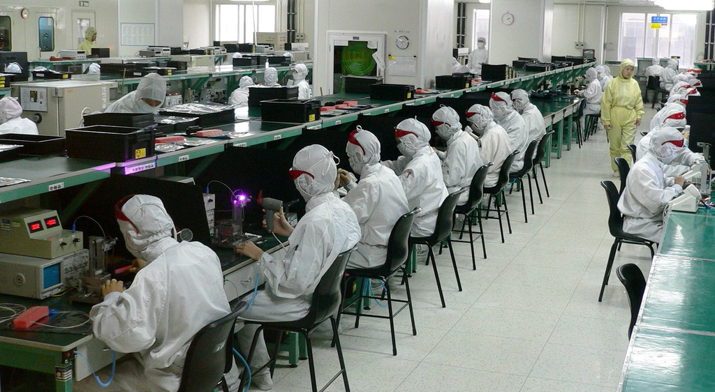

The plants were sold, and the know-how went with them. By 2010 the largest was Foxconn.

Steve Jurvetson, [Electronics factory in Shenzhen](https://commons.wikimedia.org/wiki/File:Electronics_factory_in_Shenzhen.jpg), 2005 · Wikimedia Commons, CC BY 2.0.

# Doha, November 11, 2001. After fifteen years of negotiation, China signs its accession to the World Trade Organization.

## Also in 2001: the iPod launches

[figure not shown]

Apple, the first iPod, 2001 · press photograph, supplied by the instructor.

Apple designed the iPod in Cupertino and never assembled one.

Inventec, a Taiwanese contractor, built it from 2001, and by 2006 Foxconn was building iPod nanos at Longhua.

The product that began the digital era was built by contractors from day 1.

# Apple and Foxconn both crossed a border. What is a multinational, and how does it operate?

## FDI defines a multinational

10%

of the voting shares is what distinguishes FDI from portfolio investment

A foreign fund that owns one percent of Apple is a portfolio investor; the stake gives it no say.

A direct investor holds 10 percent or more of a foreign firm’s voting shares.

A multinational owns or controls operations in more than one country through direct investment.

## American firms own $7 trillion of business abroad

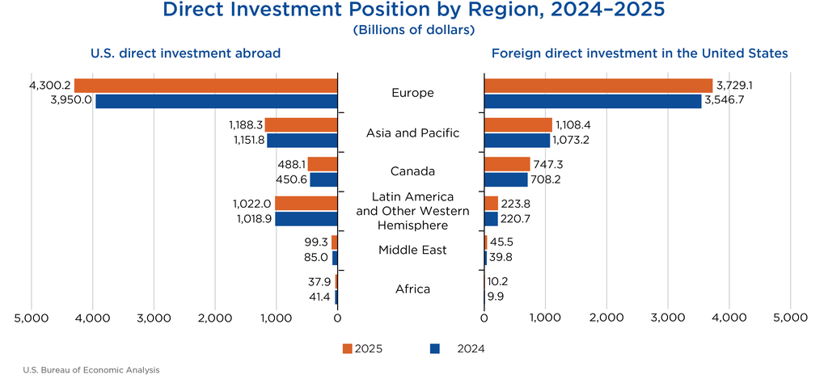

Six of every ten dollars, in both directions, sit in Europe. Ireland alone holds $512 billion of American investment.

U.S. Bureau of Economic Analysis, [Direct Investment by Country and Industry, 2025](https://www.bea.gov/news/2026/direct-investment-country-and-industry-2025), July 21, 2026 · U.S. government work, public domain.

## FDI can be a new plant or an acquisition

A greenfield investor builds a new plant, as Apple did in Cork in 1980.

An acquisition buys what already exists, as Lenovo bought IBM’s PC business in 2005.

In 2025 firms announced $1.1 trillion of greenfield projects, half of it in communications and renewables.

[figure not shown]

Visual Capitalist, [Top Sectors for Global Foreign Direct Investment in 2025](https://www.visualcapitalist.com/the-top-sectors-for-international-investment-in-2025/), 2026, data fDi Markets · Copyright Visual Capitalist, used for classroom discussion.

Both end in ownership; they differ in what the investor starts with.

## Half of U.S. imports come from a related party

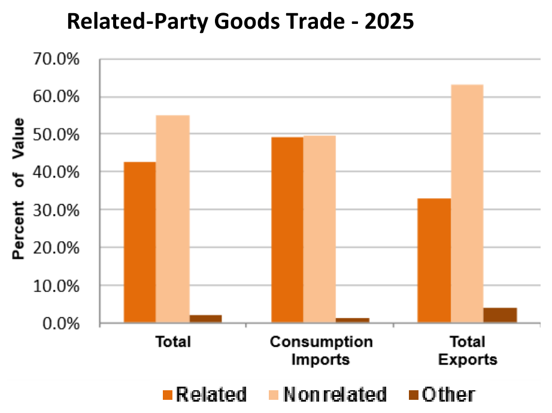

U.S. Census Bureau, total trade [U.S. Goods Trade: Imports and Exports by Related-Parties, 2025](https://www.census.gov/foreign-trade/Press-Release/related_party/rp25.pdf), July 7, 2026 · U.S. government work, public domain.

Related-party trade, also called intrafirm trade, runs between a parent and a firm it owns a stake in.

It comes after direct investment, once a parent has a plant abroad to ship to and from.

Related parties account for 49 percent of imports and 33 percent of exports.

Nearly half of U.S. goods trade is settled inside a firm, not on a market.

## Related-party trade has grown with trade itself

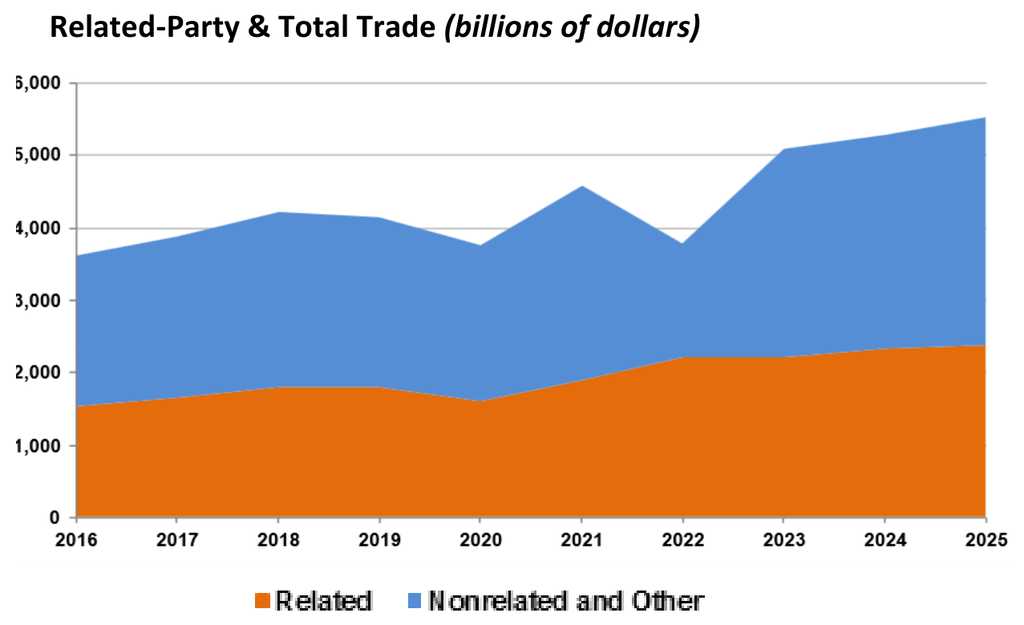

Related-party trade has risen 55 percent since 2016, in step with total trade, and its share has stayed between two fifths and three fifths.

U.S. Census Bureau, [U.S. Goods Trade: Imports and Exports by Related-Parties, 2025](https://www.census.gov/foreign-trade/Press-Release/related_party/rp25.pdf), July 7, 2026 · U.S. government work, public domain.

## Location and ownership are separate choices

[figure not shown]

Offshoring moves the work abroad and outsourcing hands it to another firm; Apple did the first in 1980 and the second around 2000.

## Related-party exports

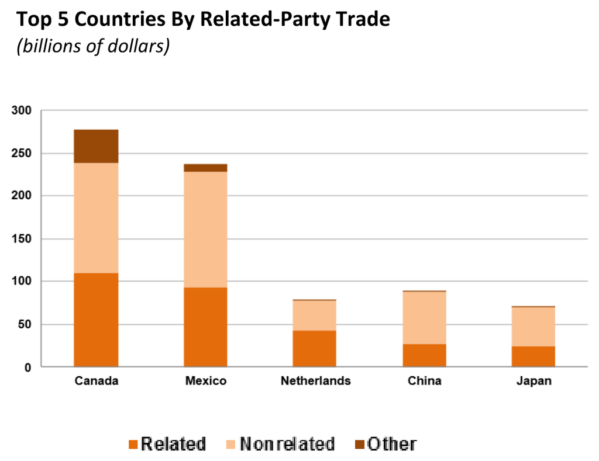

U.S. Census Bureau, [U.S. Goods Trade: Imports and Exports by Related-Parties, 2025](https://www.census.gov/foreign-trade/Press-Release/related_party/rp25.pdf), July 7, 2026 · Other trade is the estimate for shipments with a missing related-party status indicator.

About two fifths of exports to Canada and to Mexico are related.

For China the share is under a third.

Foreign-owned plants in America tend to import from their parents, while American-owned plants abroad tend to make what they sell.

## Related-party imports

Two thirds of imports from Mexico come from plants U.S. firms own.

Nearly all imports from Ireland come from Irish units of U.S. drug and technology firms.

Imports from Japan and Germany mostly come from parents supplying their U.S. units.

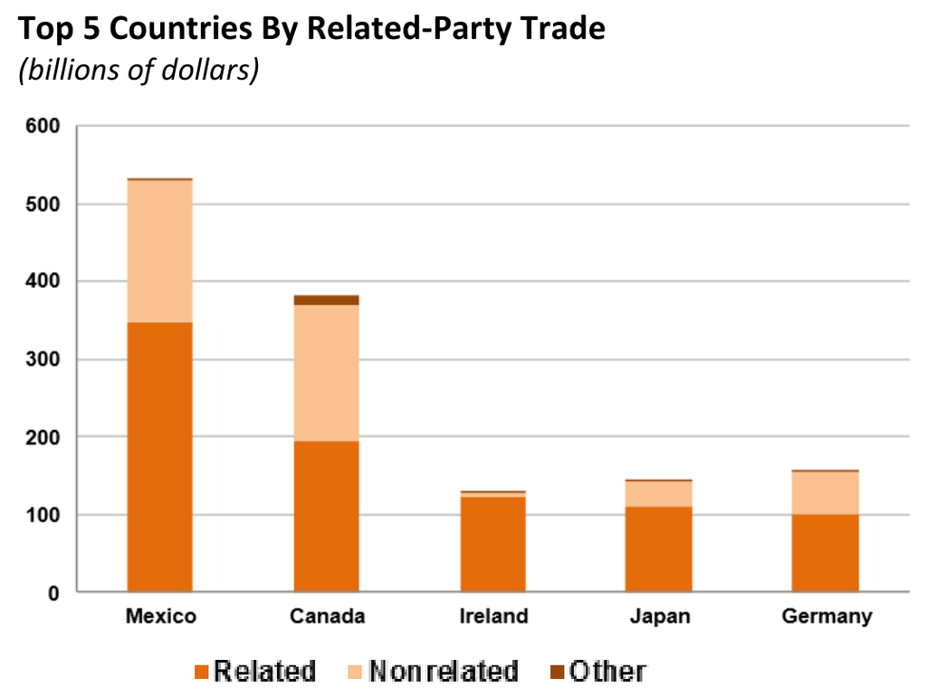

U.S. Census Bureau, [U.S. Goods Trade: Imports and Exports by Related-Parties, 2025](https://www.census.gov/foreign-trade/Press-Release/related_party/rp25.pdf), July 7, 2026 · U.S. government work, public domain.

Each of these is foreign direct investment on the grid, a firm running its own plant abroad.

## US related-party imports peaked

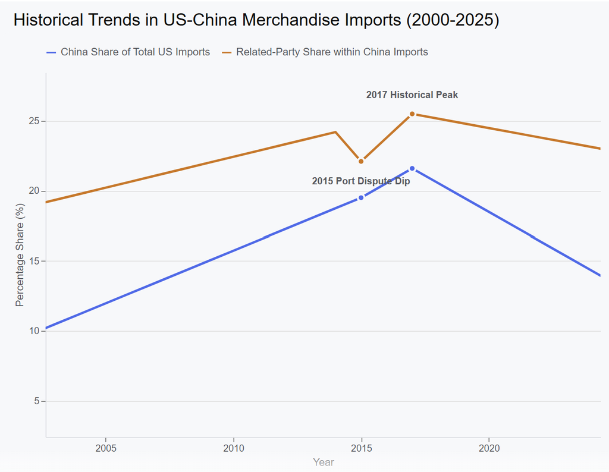

Instructor’s figure from U.S. Census Bureau related-party trade data, 2002–2025 (underlying source to be confirmed).

China’s share of U.S. imports rose to a fifth by 2017, so the work moved.

Only a quarter of those imports come from related parties; the other three quarters come from firms Americans do not own, such as Foxconn.

Most of what China ships to America is offshore outsourcing, not foreign direct investment.

# Why own a plant abroad when you could buy from one?

## Industry characteristics shape incentives

[figure not shown]

Redrawn from Pol Antràs, [Firms, Contracts, and Trade Structure](https://doi.org/10.1162/003355303322552829), 2003, Figure 1 and Table 2.

Where the parent relies on capital and research, it tends to own the plant abroad.

Where the supplier’s workers and the parent’s design can be written into a specification, the parent tends to buy.

Chemicals and drugs are the first kind of industry; electronics assembly, textiles are the second.

## Chemicals have lots of related-party exports

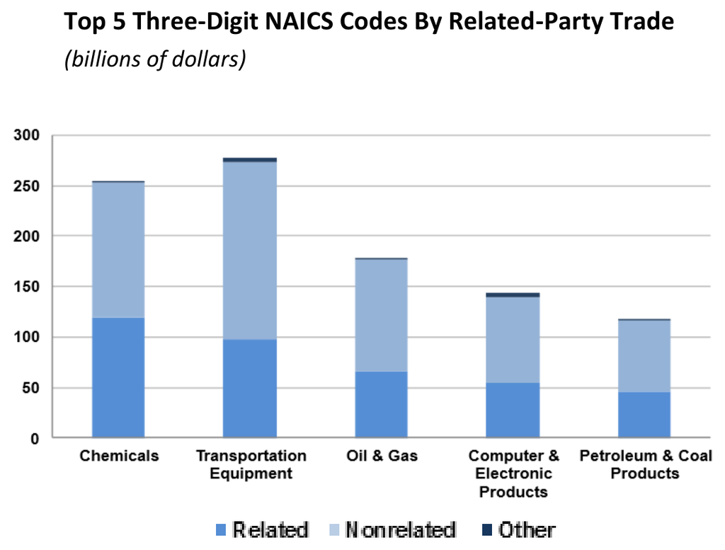

Exports data. Drug and chemical firms bring the capital, the patents, and the process, so they own the plants abroad and ship between them; nearly half of these exports are intrafirm.

U.S. Census Bureau, Exports [U.S. Goods Trade: Imports and Exports by Related-Parties, 2025](https://www.census.gov/foreign-trade/Press-Release/related_party/rp25.pdf), July 7, 2026 · U.S. government work, public domain.

## Electronics imports are more arms’ length

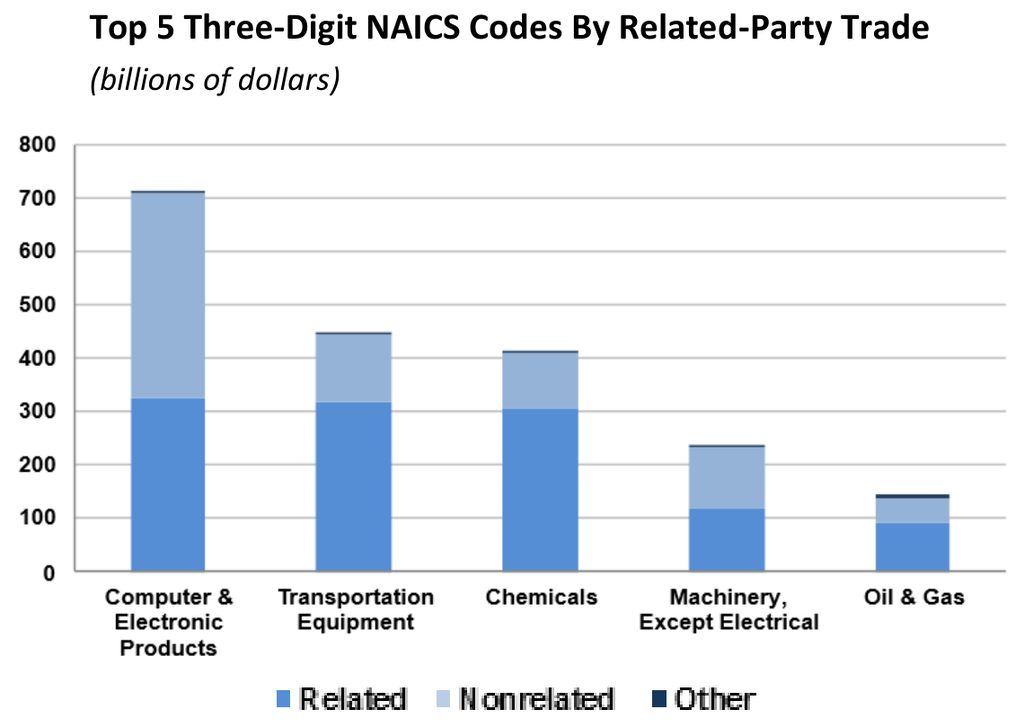

Imports data. In electronics the supplier’s plant and labor are the investment that matters at assembly, and the design stays home, so brands can buy at arm’s length. Under half of these imports are intrafirm.

U.S. Census Bureau, Imports [U.S. Goods Trade: Imports and Exports by Related-Parties, 2025](https://www.census.gov/foreign-trade/Press-Release/related_party/rp25.pdf), July 7, 2026 · U.S. government work, public domain.

## Both costs shifted and so did Apple’s boundary

[figure not shown]

Doing it inside became expensive post 2000 crash.

Buying got cheaper when Foxconn paid for the molds, Shenzhen’s suppliers moved nearby and the WTO opened markets to China’s exports.

Some advantages are cheaper to carry inside the firm than to sell abroad, and the rest are bought at arms’ length.

# Group Activity: Govern One Relationship Across a Border

## Govern one relationship across a border

1. **Select:** the relationship your team chose on Monday, or a new one between a firm in your industry and a partner abroad.
2. **Diagnose:** a key transaction cost, or industry feature.
3. **Recommend:** a market contract, a relationship with rules, or ownership abroad.

**15 minutes** · Existing industry teams · No additional research

Be ready to explain the relationship, the transaction cost, and the recommended arrangement

## Report out

Which transaction cost drove your recommendation, and what did the border change?

Sort the board into relationships a contract can govern across a border and relationships where the firm has to own the plant.

# A firm owns its operation abroad when owning is cheaper than contracting to a local firm. Otherwise it outsources from the local firm.

## Return to your opening response

Why did the same work leave Apple’s boundary and enter Foxconn’s?

Next Monday, Fallows’s “China Makes, the World Takes,” we ask why so much manufacturing ended up in China